# Is Australia Doing Well? The Widening Blind Spot in ‘It’s Green Again’

## 4 4. EDA

```python
events[["heat_anomaly_postfire", "ndvi_recovery_ratio", "sightings_recovery_ratio", "recovery_gap"]].describe()
```

|  | heat_anomaly_postfire | ndvi_recovery_ratio | sightings_recovery_ratio | recovery_gap |
| --- | --- | --- | --- | --- |
| count | 55.000000 | 55.000000 | 55.000000 | 55.000000 |
| mean | 2.055925 | 4.129325 | 22.348452 | -0.471584 |
| std | 6.197890 | 9.987900 | 72.034206 | 2.242787 |
| min | -19.524952 | 0.079690 | 0.059598 | -5.541866 |
| 25% | 0.160999 | 1.250786 | 1.088694 | -2.284491 |
| 50% | 1.340810 | 2.139844 | 2.480594 | -0.673889 |
| 75% | 3.115918 | 3.603803 | 14.898754 | 1.138846 |
| max | 19.456584 | 74.078020 | 516.663183 | 5.183761 |

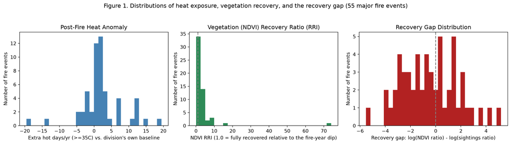

```python
fig, axes = plt.subplots(1, 3, figsize=(15, 4))

axes[0].hist(events["heat_anomaly_postfire"], bins=30, color="steelblue")
axes[0].set_title("Post-Fire Heat Anomaly")
axes[0].set_xlabel("Extra hot days/yr (>=35C) vs. division's own baseline")
axes[0].set_ylabel("Number of fire events")

axes[1].hist(events["ndvi_recovery_ratio"], bins=30, color="seagreen")
axes[1].axvline(1.0, color="grey", ls="--")
axes[1].set_title("Vegetation (NDVI) Recovery Ratio (RRI)")
axes[1].set_xlabel("NDVI RRI (1.0 = fully recovered relative to the fire-year dip)")
axes[1].set_ylabel("Number of fire events")

axes[2].hist(events["recovery_gap"], bins=30, color="firebrick")
axes[2].axvline(0, color="grey", ls="--")
axes[2].set_title("Recovery Gap Distribution")
axes[2].set_xlabel("Recovery gap: log(NDVI ratio) - log(sightings ratio)")
axes[2].set_ylabel("Number of fire events")

fig.suptitle("Figure 1. Distributions of heat exposure, vegetation recovery, and the recovery gap "
             f"({len(events)} major fire events)", y=1.04)
plt.tight_layout()
plt.show()
```

## 5 5. Interactive map: where does the gap show up?

Each fire-prone division’s **mean recovery gap** across all its major-fire events, 1982-2022. Red = vegetation recovers substantially better than wildlife (the “greenwashing risk” divisions); blue = the two track each other. Hover any division for its heat exposure and both recovery ratios.

```python
div_agg = events.groupby(["ADM1_NAME", "ADM2_NAME"]).agg(
    n_events=("recovery_gap", "size"),
    mean_recovery_gap=("recovery_gap", "mean"),
    mean_heat_anomaly=("heat_anomaly_postfire", "mean"),
    mean_ndvi_ratio=("ndvi_recovery_ratio", "mean"),
    mean_sightings_ratio=("sightings_recovery_ratio", "mean"),
).reset_index()

admin2 = gpd.read_file(os.path.join(DATA_DIR, "au_admin2_boundaries.geojson"))[["ADM1_NAME", "ADM2_NAME", "geometry"]]
geo = admin2.merge(div_agg[["ADM2_NAME"]], on="ADM2_NAME", how="inner").reset_index(drop=True)
geo["geometry"] = geo.geometry.simplify(0.01, preserve_topology=True)  # keeps the embedded map lightweight
geojson = json.loads(geo.to_json())

div_agg_labelled = div_agg.rename(columns={
    "ADM1_NAME": "State",
    "mean_recovery_gap": "Mean recovery gap",
    "mean_heat_anomaly": "Mean post-fire heat anomaly (extra hot days/yr)",
    "mean_ndvi_ratio": "Mean NDVI recovery ratio",
    "mean_sightings_ratio": "Mean sightings recovery ratio",
    "n_events": "Number of major fire events",
})

fig_map = px.choropleth_map(
    div_agg_labelled,
    geojson=geojson,
    locations="ADM2_NAME",
    featureidkey="properties.ADM2_NAME",
    color="Mean recovery gap",
    color_continuous_scale="RdBu_r",
    color_continuous_midpoint=0,
    hover_name="ADM2_NAME",
    hover_data={
        "State": True,
        "Mean recovery gap": ":.2f",
        "Mean post-fire heat anomaly (extra hot days/yr)": ":.1f",
        "Mean NDVI recovery ratio": ":.2f",
        "Mean sightings recovery ratio": ":.2f",
        "Number of major fire events": True,
    },
    map_style="carto-positron",
    zoom=3.2,
    center={"lat": -28, "lon": 145},
    opacity=0.75,
    height=650,
)
fig_map.update_layout(
    title=dict(
        text="Figure 2. Mean Post-Fire Recovery Gap by Fire-Prone Division<br>"
             "<sup>Red = vegetation recovers better than wildlife (widening blind-spot risk); Blue = the two track together</sup>",
        x=0.02, y=0.98,
    ),
    margin=dict(l=0, r=0, t=70, b=0),
    coloraxis_colorbar=dict(title="Mean recovery gap<br>(+ = vegetation<br>outpaces wildlife)"),
)
fig_map
```

[interactive chart not shown]

Divisions with a high mean gap tend to be inland/western-fringe fire-prone LGAs – the same places that also run hotter post-fire heat anomalies, which is exactly the pattern the statistical tests below confirm formally.

## 6 6. Visual evidence

### 6.1 6.1 Diverging recovery lines

The single clearest picture of the claim: plot both recovery ratios (log scale, 0 = back to baseline) against post-fire heat exposure and fit a trend line to each.

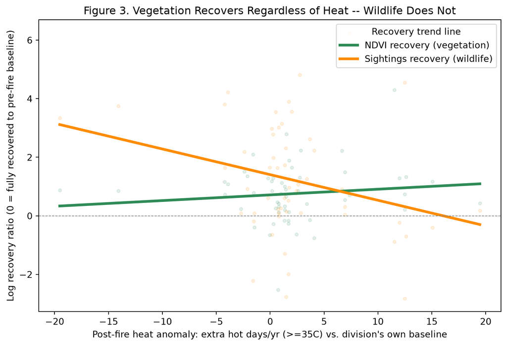

```python
fig, ax = plt.subplots(figsize=(8, 5.5))
xs = np.linspace(events["heat_anomaly_postfire"].min(), events["heat_anomaly_postfire"].max(), 50)
z_ndvi = np.polyfit(events["heat_anomaly_postfire"], events["log_ndvi_ratio"], 1)
z_sight = np.polyfit(events["heat_anomaly_postfire"], events["log_sight_ratio"], 1)

ax.scatter(events["heat_anomaly_postfire"], events["log_ndvi_ratio"], alpha=0.12, s=12, color="seagreen")
ax.scatter(events["heat_anomaly_postfire"], events["log_sight_ratio"], alpha=0.12, s=12, color="darkorange")
ax.plot(xs, np.polyval(z_ndvi, xs), color="seagreen", lw=3, label="NDVI recovery (vegetation)")
ax.plot(xs, np.polyval(z_sight, xs), color="darkorange", lw=3, label="Sightings recovery (wildlife)")
ax.axhline(0, color="grey", lw=0.7, ls="--")
ax.set_xlabel("Post-fire heat anomaly: extra hot days/yr (>=35C) vs. division's own baseline")
ax.set_ylabel("Log recovery ratio (0 = fully recovered to pre-fire baseline)")
ax.set_title("Figure 3. Vegetation Recovers Regardless of Heat -- Wildlife Does Not")
ax.legend(title="Recovery trend line", loc="upper right")
plt.tight_layout()
plt.show()
```

The vegetation line is nearly flat across the entire heat range. The wildlife line starts *above* vegetation at low heat exposure (sightings often overshoot their pre-fire baseline when conditions are mild) and drops steadily as heat exposure rises, crossing below vegetation and continuing down. The vertical distance between the two lines *is* the recovery gap – and it visibly grows left to right.